# 11

```python
import pandas as pd
import seaborn as sns
```

```python
hostels = pd.read_csv('../data/hostel.csv')
penguins = sns.load_dataset("penguins")
```

### Portfolio assignment 11

20 min: Do a Numerical VS Categorical bivariate analysis on the penguins dataset.

- Choose one of the categorical columns: species, island or sex
- use .groupby('').mean() too look at the means of the numerical columns. Does it look like there is a difference between categories?
- Use the seaborn barplot to plot the mean and confidence. Create this plot for each of the numerical columns (bill_length_mm bill_depth_mm, flipper_length_mm, body_mass_g)
- For each of the plots, write a conclusion: Is there a statistically significant difference for this numerical column for each category?
- Optional: Repeat this proces for the other two categorical columns

As seen below the Biscoe island shows values that are off compared to the values on the Dream and Torgersen island. The flipper length and body mass are higher than on the other two island. On the Torgersen island the mean for the bill length is a lot lower than on the other island with a similar mean of around 44-45.

```python
penguins.groupby(["island"]).mean()
```

| island | bill_length_mm | bill_depth_mm | flipper_length_mm | body_mass_g |
| --- | --- | --- | --- | --- |
| Biscoe | 45.257485 | 15.874850 | 209.706587 | 4716.017964 |
| Dream | 44.167742 | 18.344355 | 193.072581 | 3712.903226 |
| Torgersen | 38.950980 | 18.429412 | 191.196078 | 3706.372549 |

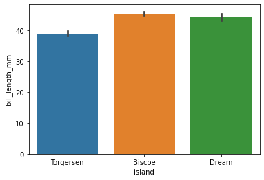

```python
sns.barplot(y="bill_length_mm", x="island", data=penguins)
```

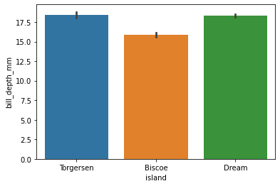

```python
sns.barplot(y="bill_depth_mm", x="island", data=penguins)
```

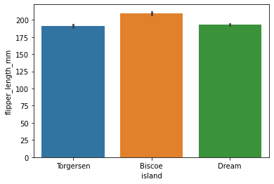

```python
sns.barplot(y="flipper_length_mm", x="island", data=penguins)
```

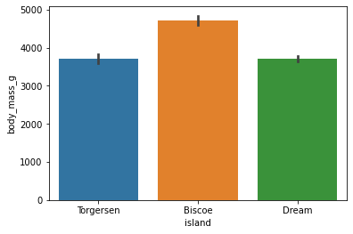

```python
sns.barplot(y="body_mass_g", x="island", data=penguins)
```